# CSU ESS330: Final Project

Authors

Affiliation

Olivia Gilpin

Colorado State University

Josh Ray

Colorado State University

## Assessing the Impact of Livestock Populations on Nitrous Oxide Emissions by Livestock

Authors: Olivia Gilpin & Josh Ray

### Introduction

Greenhouse gas emissions have significantly increased over the past few decades, reaching the tipping points of atmospheric and ocean absorption, which has caused catastrophic effects globally. These catastrophic impacts include severe disruptions to weather patterns and ecosystems, which have in turn have globally threatened biodiversity and human health (Filonchyk et al., 2024). The emissions of Greenhouse Gases are primarily derived from various inputs into the atmosphere, heavily including inputs from agricultural processes (Filonchyk et al., 2024). Nitrous oxide, a main Greenhouse Gas emission, is a key contributor to climate change, driven by anthropogenic effects, which have a significant contribution to overall global emissions (Omemen & Aldbbah, 2025). This study will focus on the key component of the greenhouse gas nitrous oxide emissions in correlation to agricultural processes.

For this research, we are asking, will the livestock population of livestock have an impact on the level of nitrous oxide emissions? We hypothesize that as the population of livestock increases, the emissions of nitrous oxide will increase. The null hypothesis, if there is no significant relationship between livestock population size and nitrous oxide emissions, an increase in livestock population does not lead to an increase in nitrous oxide emissions. The objective of this study is to evaluate the relationship between livestock emissions and greenhouse gas emissions, specifically nitrous oxide. Through this research objective, the goal is to assess whether the population of livestock emissions will influence nitrous oxide emissions.

Agricultural emissions can be further assessed utilizing longitudinal data analysis, climate models, and remote sensing through the long-term monitoring of the atmosphere. Understanding the environmental consequences of nitrous oxide emissions impacts every sector of life on earth, in addition to the environmental impacts, such as economic, social, and cultural intersections (Yılmaz & Ozaner, 2025). Economic impacts can include the stability or instability of crop yield, which has an impact on the global food market and costs. Culturally, the impact on human health from the decline of air quality can have cultural disruptions within communities, especially those dependent on the natural earth cycles. Through further understanding of the interconnectedness of global nitrous oxide emissions, stakeholders can be better informed about combating the consequences and creating interdisciplinary frameworks. Stakeholders would include agricultural workers, agricultural producers and managers, policymakers, and environmental agencies. These stakeholders will need to work towards collaborating and creating policies that are ecologically sustainable and socio-economically equitable to assure a well-rounded approach for the benefit of all stakeholders and global impact considerations.

### Methods

We acquired data from Marshall & Hanson (2024) for this study, which focused on greenhouse gas emissions in correlation to agriculture and forestry-related emissions. From the numerous datasets they provide on the inventory dashboard, we utilized the nitrous oxide Emissions from Livestock Manure Management Systems and the Population of Livestock. The acquired data had a temporal range of 01/01/1990 through 12/21/2022, obtained at an annual frequency, and geographically covered the United States, including all 50 states. These datasets were utilized due to their direct alignment with testing our hypothesis of testing if the population of livestock would have an impact on the level of nitrous oxide emissions.

Through examining the relationship between nitrous oxide livestock emissions and livestock populations, we took a comparative and statistical analysis approach. This approach included an initial establishment of emission baselines, utilizing national livestock populations and the total nitrous oxide emissions (Marshall & Hanson, 2024). We then utilized the data on nitrous oxide livestock emissions from livestock and analyzed that in comparison to the research on climate variability effects from agricultural practices (Bhatti et al., 2024; Filonchyk et al., 2024; Gołasa et al., 2021; Marshall & Hanson, 2024). We conducted a cross-comparison of nitrous oxide livestock emissions and livestock populations, in order to correlate livestock populations with nitrous oxide livestock emissions, and determine if reductions in livestock populations have an influence on the total outputs of nitrous oxide from livestock.

For data processing and analysis, we used RStudio, Version 2024.12.1+563 (2024.12.1+563), utilizing various packages to interpret our data, including dplyr, janitor, ggplot2, mediation, readxl, and tidyr. The two primary datasets were saved in our data file as an xlsx file and exported from Excel files using the readxl package for ‘Population of Livestock’ and ‘Nitrous Oxide Emissions from Livestock Manure Management Systems’. After importing and reading the data, we performed several data cleaning steps, including standardizing variable names using the clean_names() function, removing records with missing values (drop_na()), and eliminating duplicate entries (distinct()). We then filtered both datasets in order to specifically focus on the data records categorized as ‘Population of Livestock’ and ‘Nitrous Oxide Emissions from Livestock Manure Management Systems’. In order to compare across variables, we combined the two datasets by year, summing the total livestock population and total nitrous oxide emissions values for each year. These consolidated datasets were then merged using a left join operation based on the year variable, creating a combined dataset with matched annual records of livestock populations and corresponding emissions.

The statistical analysis portion consisted of us conducting a Pearson correlation test to quantify the relationship between livestock population and nitrous oxide emissions. We then developed a linear regression model with livestock population as the independent variable and nitrous oxide emissions as the dependent variable. The results were visualized using scatter plots with regression lines and time series plots showing emission trends across years. All visualizations were created using ggplot2 and saved as PNG files for reporting purposes.

### Results

#### Results Code:

```r
knitr::opts_chunk$set(echo = TRUE)

library(dplyr)
```

```r
library(janitor)
```

```r
library(ggplot2)
library(mediation)
```

```r
library(readxl)
library(tidyr)
```

```r
library(flextable)

sheet1_path <- "data/Population of Livestock.xlsx"
sheet2_path <- "data/Nitrous Oxide Emissions from Livestock Manure Management Systems.xlsx"
data1 <- read_excel(sheet1_path)
data2 <- read_excel(sheet2_path)

str(data1)
```

```
tibble [42,900 × 7] (S3: tbl_df/tbl/data.frame)
 $ state_long                : chr [1:42900] "Alaska" "Alaska" "Alaska" "Alaska" ...
 $ state_short               : chr [1:42900] "AK" "AK" "AK" "AK" ...
 $ supplemental_category     : chr [1:42900] "Population of Livestock" "Population of Livestock" "Population of Livestock" "Population of Livestock" ...
 $ supplemental_subcategory_1: chr [1:42900] "Beef NOF Bull" "Beef NOF Bull" "Beef NOF Bull" "Beef NOF Bull" ...
 $ unit                      : chr [1:42900] "1,000 head" "1,000 head" "1,000 head" "1,000 head" ...
 $ value                     : num [1:42900] 1.6 1.7 1.5 1.3 1.6 1.9 2.4 2.9 2 1.9 ...
 $ year                      : chr [1:42900] "2000" "2001" "2002" "2003" ...
```

```r
str(data2)
```

```
tibble [117,150 × 9] (S3: tbl_df/tbl/data.frame)
 $ ghg                       : chr [1:117150] "N₂O" "N₂O" "N₂O" "N₂O" ...
 $ state_long                : chr [1:117150] "Alaska" "Alaska" "Alaska" "Alaska" ...
 $ state_short               : chr [1:117150] "AK" "AK" "AK" "AK" ...
 $ supplemental_category     : chr [1:117150] "Nitrous Oxide Emissions from Livestock Manure Management Systems" "Nitrous Oxide Emissions from Livestock Manure Management Systems" "Nitrous Oxide Emissions from Livestock Manure Management Systems" "Nitrous Oxide Emissions from Livestock Manure Manage…
 $ supplemental_subcategory_1: chr [1:117150] "Beef OF Heifers" "Beef OF Heifers" "Beef OF Heifers" "Beef OF Heifers" ...
 $ supplemental_subcategory_2: chr [1:117150] "Cattle Deep Litter (>1 month)" "Cattle Deep Litter (>1 month)" "Cattle Deep Litter (>1 month)" "Cattle Deep Litter (>1 month)" ...
 $ unit                      : chr [1:117150] "MMT CO₂e" "MMT CO₂e" "MMT CO₂e" "MMT CO₂e" ...
 $ value                     : num [1:117150] 0 0 0 0 0 0 0 0 0 0 ...
 $ year                      : chr [1:117150] "2000" "2001" "2002" "2003" ...
```

```r
data1 <- data1 %>%
  clean_names() %>%
  drop_na() %>%
  distinct()
data2 <- data2 %>%
  clean_names() %>%
  drop_na() %>%
  distinct()

data_livestock <- data1 %>%
  filter(supplemental_category == "Population of Livestock")
data_emissions <- data2 %>%
  filter(supplemental_category == "Nitrous Oxide Emissions from Livestock Manure Management Systems")
data_livestock_aggregated <- data_livestock %>%
  group_by(year) %>%
  summarise(value_livestock = sum(value, na.rm = TRUE))
data_emissions_aggregated <- data_emissions %>%
  group_by(year) %>%
  summarise(value_emissions = sum(value, na.rm = TRUE))
data_combined <- left_join(data_livestock_aggregated, data_emissions_aggregated, by = "year")

ft_combined <- flextable(head(data_combined)) %>%
  set_caption("Combined Livestock Population and Emissions Data (First 6 Rows)") %>%
  theme_vanilla() %>%
  autofit()

ft_combined
```

| year | value_livestock | value_emissions |
| --- | --- | --- |
| 1990 | 1,708,300 | 13.36211 |
| 1991 | 1,768,507 | 13.53875 |
| 1992 | 1,827,374 | 13.54686 |
| 1993 | 1,885,013 | 13.36723 |
| 1994 | 1,950,493 | 13.99932 |
| 1995 | 2,009,101 | 14.34884 |

```r
correlation_result <- cor.test(data_combined$value_livestock, data_combined$value_emissions)
print("Correlation Analysis:")
```

```
[1] "Correlation Analysis:"
```

```r
print(correlation_result)
```

```
    Pearson's product-moment correlation

data:  data_combined$value_livestock and data_combined$value_emissions
t = 16.043, df = 31, p-value < 2.2e-16
alternative hypothesis: true correlation is not equal to 0
95 percent confidence interval:
 0.8901091 0.9725917
sample estimates:
      cor
0.9447263
```

```r
cor_data <- data.frame(
  Statistic = c("Correlation coefficient", "p-value", "95% CI lower", "95% CI upper"),
  Value = c(correlation_result$estimate, correlation_result$p.value,
            correlation_result$conf.int[1], correlation_result$conf.int[2])
)
ft_correlation <- flextable(cor_data) %>%
  set_caption("Correlation Analysis Results") %>%
  theme_vanilla() %>%
  autofit()

ft_correlation
```

| Statistic | Value |
| --- | --- |
| Correlation coefficient | 0.9447262943590902795066 |
| p-value | 0.0000000000000001452862 |
| 95% CI lower | 0.8901090771934415668554 |
| 95% CI upper | 0.9725916788484249009272 |

```r
regression_model <- lm(value_emissions ~ value_livestock, data = data_combined)
print("Linear Regression Model Summary:")
```

```
[1] "Linear Regression Model Summary:"
```

```r
print(summary(regression_model))
```

```
Call:
lm(formula = value_emissions ~ value_livestock, data = data_combined)

Residuals:
     Min       1Q   Median       3Q      Max
-0.64892 -0.25862 -0.03008  0.21603  0.77258

Coefficients:
                 Estimate Std. Error t value Pr(>|t|)
(Intercept)     4.617e+00  6.691e-01    6.90 9.75e-08 ***
value_livestock 4.813e-06  3.000e-07   16.04  < 2e-16 ***
---
Signif. codes:  0 '***' 0.001 '**' 0.01 '*' 0.05 '.' 0.1 ' ' 1

Residual standard error: 0.3438 on 31 degrees of freedom
Multiple R-squared:  0.8925,    Adjusted R-squared:  0.889
F-statistic: 257.4 on 1 and 31 DF,  p-value: < 2.2e-16
```

```r
reg_data <- data.frame(
  Coefficient = c("Intercept", "value_livestock"),
  Estimate = c(coef(regression_model)[1], coef(regression_model)[2]),
  `Std. Error` = c(summary(regression_model)$coefficients[1,2],
                   summary(regression_model)$coefficients[2,2]),
  `t value` = c(summary(regression_model)$coefficients[1,3],
                summary(regression_model)$coefficients[2,3]),
  `Pr(>|t|)` = c(summary(regression_model)$coefficients[1,4],
                 summary(regression_model)$coefficients[2,4])
)
ft_regression <- flextable(reg_data) %>%
  set_caption("Linear Regression Results") %>%
  theme_vanilla() %>%
  autofit()

ft_regression
```

| Coefficient | Estimate | Std..Error | t.value | Pr...t.. |
| --- | --- | --- | --- | --- |
| Intercept | 4.616787798665 | 0.6690580525830 | 6.900429 | 0.0000000975270375742554 |
| value_livestock | 0.000004812501 | 0.0000002999663 | 16.043470 | 0.0000000000000001452862 |

```r
model_summary <- data.frame(
  Statistic = c("R-squared", "Adjusted R-squared", "F-statistic", "p-value"),
  Value = c(summary(regression_model)$r.squared,
            summary(regression_model)$adj.r.squared,
            summary(regression_model)$fstatistic[1],
            pf(summary(regression_model)$fstatistic[1],
               summary(regression_model)$fstatistic[2],
               summary(regression_model)$fstatistic[3], lower.tail = FALSE))
)
ft_model_summary <- flextable(model_summary) %>%
  set_caption("Regression Model Summary Statistics") %>%
  theme_vanilla() %>%
  autofit()

ft_model_summary
```

| Statistic | Value |
| --- | --- |
| R-squared | 0.8925077712534587037752 |
| Adjusted R-squared | 0.8890402800035702712833 |
| F-statistic | 257.3929411594556881937024 |
| p-value | 0.0000000000000001452862 |

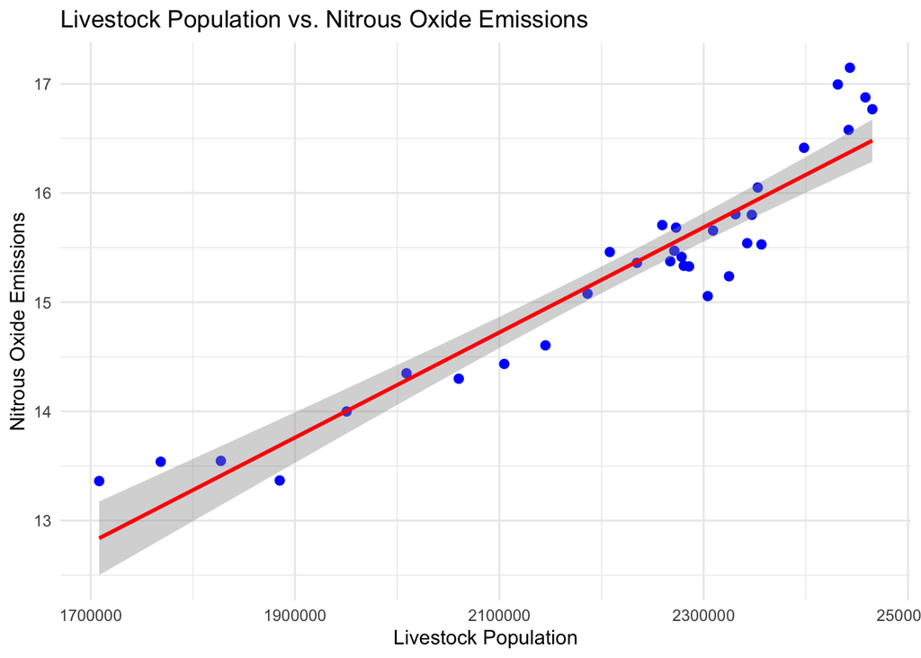

```r
p1 <- ggplot(data_combined, aes(x = value_livestock, y = value_emissions)) +
  geom_point(color = "blue", size = 2) +
  geom_smooth(method = "lm", se = TRUE, color = "red") +
  theme_minimal() +
  labs(title = "Livestock Population vs. Nitrous Oxide Emissions",
       x = "Livestock Population",
       y = "Nitrous Oxide Emissions")
print(p1)
```

```r
ggsave("scatter_regression_plot.png", plot = p1, width = 8, height = 6)
```

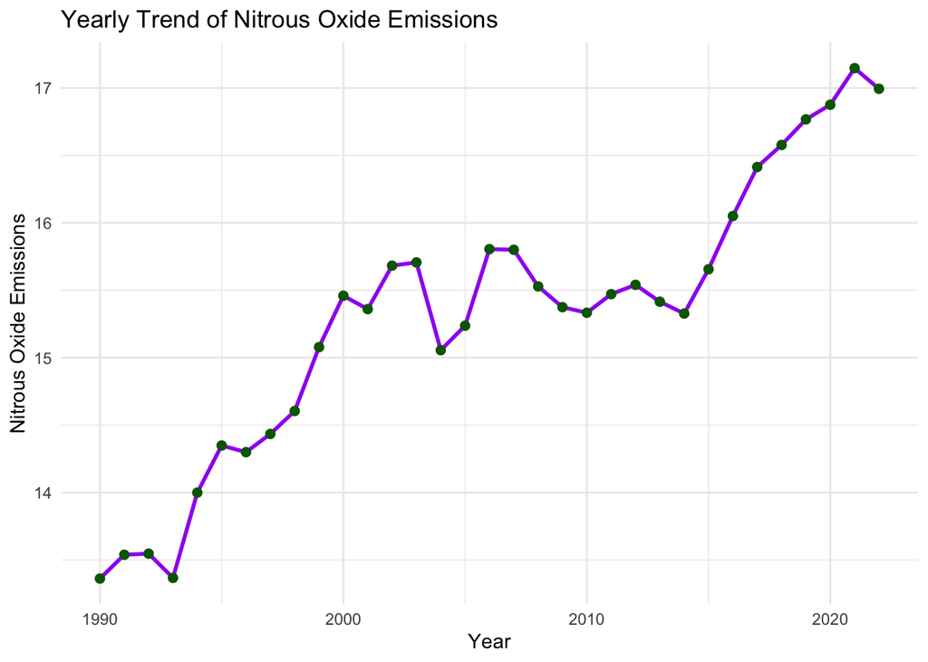

```r
data_combined <- data_combined %>%
  mutate(year = as.numeric(year)) %>%
  drop_na(year, value_emissions) %>%
  arrange(year)
p2 <- ggplot(data_combined, aes(x = year, y = value_emissions)) +
  geom_line(color = "purple", linewidth = 1) +
  geom_point(color = "darkgreen", size = 2) +
  theme_minimal() +
  labs(title = "Yearly Trend of Nitrous Oxide Emissions",
       x = "Year",
       y = "Nitrous Oxide Emissions")
print(p2)
```

```r
ggsave("trend_emissions_plot.png", plot = p2, width = 8, height = 6)
```

#### Figures:

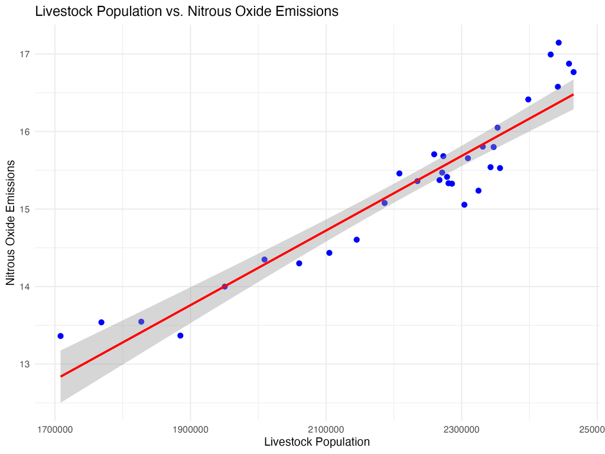

```r
knitr::include_graphics("img/scatter_regression_plot.png")
```

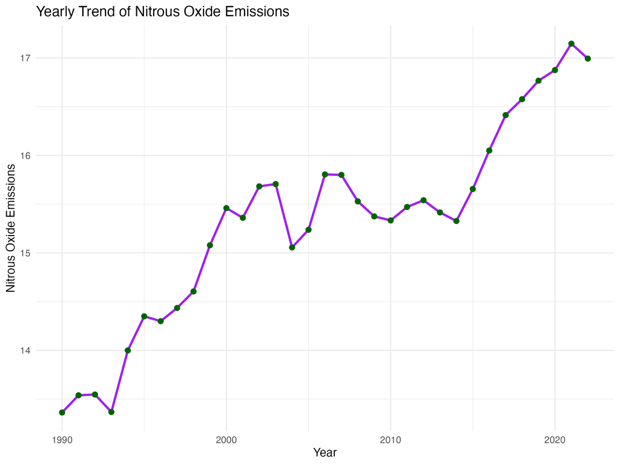

```r
knitr::include_graphics("img/trend_emissions_plot.png")
```

### Discussion/Conclusions

The results found in our research are aligned with research by Filonchyk et al. (2024), which identified that a major contributor of greenhouse gas emissions was from agricultural practices. Our research built upon this research by quantifying the relationship between a major greenhouse gas, nitrous oxide, and livestock populations, through providing quantitative evidence. Our evidence is described by researchers Omemen and Aldbbah (2025) as anthropogenic drivers of climate change. Our research on nitrous oxide emissions and the portion of emissions that derive from livestock is also consistent with that of the research by Zhang et al. (2024), which highlights that manure management in livestock farming contributes to approximately 36% of global agricultural-related nitrous oxide emissions.

When looking towards further research and mitigation, we must consider the global socio-economic perspective and implications that our findings contribute to the discussed interconnectness of environmental sustainability, economic demands, and agriculture practices, namely their complexities, by Yılmaz and Ozaner (2025). This interconnectedness raises serious concerns for agricultural stakeholders and policymakers, as finding a balance in production and protecting the planet requires a deep understanding of the effects of climate change and global agricultural systems, which includes a biogeochemical knowledge base as well. Any changes made to agricultural products have a ripple effect on global food markets, crop yields, and global health, which is why this research is valuable and essential.

The expected challenges of this research were realizing how vital the integration of the spatial dispersion of livestock populations could have been. Also, whether that could factor into nitrous oxide emission rates based on livestock in a given area and their dispersal. This challenge could help to identify if higher concentrations of livestock in a smaller area of land could impact nitrous oxide emission rates versus a larger area of land for the same amount of livestock, but they are more dispersed versus concentrated. We could consider including geographic data to address this limitation. This could be done by analyzing how livestock density in different regions might affect nitrous oxide emissions. The utilization of mapping tools as well as spatial regression models would help us to better understand if concentrated livestock populations lead to higher emissions compared to more spread-out populations.

Our cumulative findings indicate a strong positive relationship between livestock population and nitrous oxide emissions, indicating a global demand for greenhouse gas mitigation and sustainable agricultural practices. Adapting sustainable agricultural practices will be essential for the longevity of the global rising populations and production demands. Climate change mitigation will be essential alongside the adoption of sustainable agricultural practices, as we have shown the direct correlation between the two. This will require a multidisciplinary approach to mitigation, which involves stakeholders from agricultural production, policymakers, community members, environmental agencies, and non-government organizations. Our research has provided evidence to support policy changes towards climate change mitigation and sustainable agricultural practices that consider the social, economic, and environmental perspectives. The methods we suggest to limit NO2 emissions are reduced manure storage time, incorporating seaweed into the livestock feed, and developing a credit program to incentivize ranchers to limit their emissions.

### References:

(Akiyama, 2024)

(Bhatti et al., 2024)

(TRACE, n.d.)

(Filonchyk, Peterson, Zhang, Hurynovich, & He, 2024)

(Forster et al., 2024)

(Gołasa et al., 2021)

(Li, Shang, Yu, & Jiang, 2020)

(Nagelkerken & Connell, 2015)

(Omemen & Aldbbah, 2025)

(Data, n.d.)

(Siddik, Islam, Zaman, & Hasan, 2021)

(Department for Environment, Food & Rural Affairs, 2024)

(Yılmaz & Ozaner, 2025)

(Bank, n.d.)

(Zhang et al., 2024)

(Zhuang et al., 2019)

## References

Akiyama, H. (2024). Methane and nitrous oxide emissions from agricultural fields in japan and mitigation options: A review. *Soil Science and Plant Nutrition*, *70*(2), 79–87.

Bank, W. (n.d.). *World development indicators: GDP growth (annual %)*. Retrieved from https://databank.worldbank.org/reports.aspx?source=2&series=NY.GDP.MKTP.KD.ZG&country=

Bhatti, U. A., Bhatti, M. A., Tang, H., Syam, M. S., Awwad, E. M., Sharaf, M., & Ghadi, Y. Y. (2024). Global production patterns: Understanding the relationship between greenhouse gas emissions, agriculture greening and climate variability. *Environmental Research*, *245*. https://doi.org/10.1016/j.envres.2023.118049

Data, O. W. in. (n.d.). *Annual CO₂ emissions per country*. Retrieved from https://ourworldindata.org/grapher/annual-co2-emissions-per-country

Department for Environment, Food & Rural Affairs. (2024). *Agri-climate report 2023*. UK Government. Retrieved from UK Government website: https://www.gov.uk/government/statistics/agri-climate-report-2023/agri-climate-report-2023

Filonchyk, M., Peterson, M. P., Zhang, L., Hurynovich, V., & He, Y. (2024). Greenhouse gases emissions and global climate change: Examining the influence of CO2, CH4, and N2O. *Science of The Total Environment*, 173359.

Forster, P. M., Smith, C., Walsh, T., Lamb, W. F., Lamboll, R., Hall, B., et al.others. (2024). Indicators of global climate change 2023: Annual update of key indicators of the state of the climate system and human influence. *Earth System Science Data*, *16*(6), 2625–2658.

Gołasa, P., Wysokiński, M., Bieńkowska-Gołasa, W., Gradziuk, P., Golonko, M., Gradziuk, B., … Gromada, A. (2021). Sources of greenhouse gas emissions in agriculture, with particular emphasis on emissions from energy used. *Energies*, *14*(13), 3784.

Li, N., Shang, L., Yu, Z., & Jiang, Y. (2020). Estimation of agricultural greenhouse gases emission in interprovincial regions of china during 1996–2014. *Natural Hazards*, *100*(3), 1037–1058.

Nagelkerken, I., & Connell, S. D. (2015). Global alteration of ocean ecosystem functioning due to increasing human CO2 emissions. *Proceedings of the National Academy of Sciences*, *112*(43), 13272–13277.

Omemen, K. M., & Aldbbah, M. O. (2025). Climate change: Key contributors and sustainable solutions. *Int. J. Electr. Eng. And Sustain.*, 10–27.

Siddik, M., Islam, M., Zaman, A., & Hasan, M. (2021). Current status and correlation of fossil fuels consumption and greenhouse gas emissions. *Int. J. Energy Environ. Econ*, *28*, 103–119.

TRACE, C. (n.d.). *Inventory*. Retrieved from https://climatetrace.org/inventory?year_from=2023&year_to=2023&gas=co2e100

Yılmaz, S., & Ozaner, D. (2025). Causality between carbon emissions, temperature changes, and health expenditures: A comparative panel approach with environmental and economic indicators. *Sustainability (2071-1050)*, *17*(3).

Zhang, L., Pan, S., Ouyang, Z., Canadell, J. G., Chang, J., Conchedda, G., et al.others. (2024). Global nitrous oxide emissions from livestock manure during 1890–2020: An IPCC tier 2 inventory. *Global Change Biology*, *30*(5), e17303.

Zhuang, M., Lu, X., Caro, D., Gao, J., Zhang, J., Cullen, B., & Li, Q. (2019). Emissions of non-CO2 greenhouse gases from livestock in china during 2000–2015: Magnitude, trends and spatiotemporal patterns. *Journal of Environmental Management*, *242*, 40–45.